# DATA661 - Homework #1

Blandon Casenave

9/3/2017

DATA TRANSFORMATION

```r
names(outsidetemp)[names(outsidetemp)=="V1"] <- "Month"
names(outsidetemp)[names(outsidetemp)=="V2"] <- "Day"
names(outsidetemp)[names(outsidetemp)=="V3"] <- "Year"
names(outsidetemp)[names(outsidetemp)=="V4"] <- "Temp"

outsidetwoyears <-data.frame(
  outsidetemp %>%
    group_by_(.dots = c("Month","Year")) %>%
    summarize(AvgTemp=mean(Temp)))

outsidetwoyears <-outsidetwoyears[order(outsidetwoyears$Year),]

outsidetwoyears$Date = paste(outsidetwoyears$Month, outsidetwoyears$Year, sep="/")

outsidetwoyears$MY <- as.yearmon(as.character(outsidetwoyears$Date), "%m/%Y")

outsidesub <- subset(outsidetwoyears, MY >= as.yearmon("2014-07") & MY < as.yearmon("2016-07"),
select=c(MY, AvgTemp))

names(outsidesub)[names(outsidesub)=="MY"] <- "Date"


electricaldata$Date <- as.yearmon(as.character(electricaldata$End_Date), "%d-%b-%y")
electrical<-data.frame(electricaldata$Date, electricaldata$Elec)
names(electrical)[names(electrical)=="electricaldata.Date"] <- "Date"
names(electrical)[names(electrical)=="electricaldata.Elec"] <- "Kwh"

totalDF <- merge(electrical,outsidesub,by="Date")
```

Linear Regression & Summary Stats

```
##
## Call:
## lm(formula = Kwh ~ AvgTemp, data = totalDF)
##
## Residuals:
##     Min      1Q  Median      3Q     Max
## -321.55 -173.12   10.57  145.51  416.32
##
## Coefficients:
##             Estimate Std. Error t value Pr(>|t|)
## (Intercept) 2053.186    155.807  13.178 6.45e-12 ***
## AvgTemp       17.192      2.662   6.459 1.69e-06 ***
## ---
## Signif. codes:  0 '***' 0.001 '**' 0.01 '*' 0.05 '.' 0.1 ' ' 1
##
## Residual standard error: 209.3 on 22 degrees of freedom
## Multiple R-squared:  0.6547, Adjusted R-squared:  0.639
## F-statistic: 41.72 on 1 and 22 DF,  p-value: 1.692e-06
```

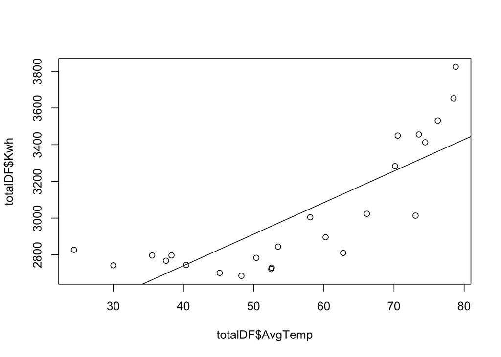

Piecewise Linear Regression Model

```
##
##  ***Regression Model with Segmented Relationship(s)***
##
## Call:
## segmented.lm(obj = energymodel, seg.Z = ~AvgTemp, psi = 70)
##
## Estimated Break-Point(s):
##    Est. St.Err
## 62.764  2.569
##
## Meaningful coefficients of the linear terms:
##             Estimate Std. Error t value Pr(>|t|)
## (Intercept) 2679.518    134.127  19.977  1.1e-14 ***
## AvgTemp        2.434      2.838   0.858    0.401
## U1.AvgTemp    50.840     10.696   4.753       NA
## ---
## Signif. codes:  0 '***' 0.001 '**' 0.01 '*' 0.05 '.' 0.1 ' ' 1
##
## Residual standard error: 120.1 on 20 degrees of freedom
## Multiple R-Squared: 0.8967,  Adjusted R-squared: 0.8812
##
## Convergence attained in 3 iterations with relative change -2.017957e-16
```

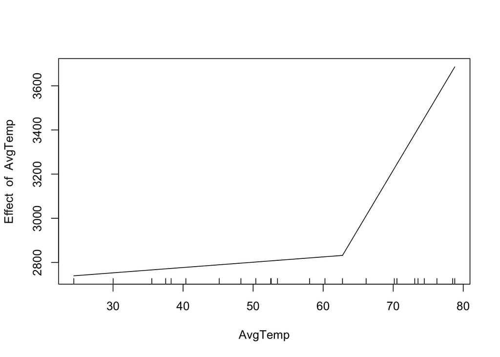

**Assignment Questions**

a-i) The first model is a standard linear regression model, with one regression line through the scatterplot of data points. We can tell that there is a reasonably strong relationship betweem outside temp and electrical usage, but that the variance appears to be unequal (heteroskedastic) across our data set. The second model, with our segmented regression instead has two regression lines connected at our breakpoint (62.7F).

a-ii) The adjusted R-squared values for model one is .64, and for the second model it’s .88, a marked improvement when moving to the piecewise model.

Source: [Piecewise Linear Regression Model](https://onlinecourses.science.psu.edu/stat501/node/310)

Source:[segmented package CRAN](https://cran.r-project.org/web/packages/segmented/segmented.pdf)

Source:[R-Bloggers Piecewise Regression](https://www.r-bloggers.com/r-for-ecologists-putting-together-a-piecewise-regression/)